# Spark MLlib

## Setup

To make my life easier, we’ll be running spark locally this week - sparklyr can be used to install a local copy

```r
# Get the latest version
sparklyr::spark_install(version= "3.3", hadoop_version = "3")
```

We won’t get all the HDFS stuff but if we’re just working with data that will fit in memeory we can prototype this way.

### Connect to local spark with sparklyr

```r
library(sparklyr)
library(dplyr)
sc = sparklyr::spark_connect("local", version="3.3")
```

### Connect to local spark with SparkR

The SparkR package is bundled with the spark distribution, so we need to add it to `.libPaths()` so we can load it. `sparklyr::spark_home_dir()` tells us where sparklyr installed spark, SparkR will then be inside the `R/lib/` path from there.

```r
.libPaths(c(
  file.path(sparklyr::spark_home_dir(), 'R/lib/'),
  .libPaths()
))
```

```r
# Careful loading this after sparklyr - function name collision issues
library(SparkR)
```

```r
# My laptop has a version of java that SparkR doesn't like
# so I need to tell it where to find an older version
# (installed via homebrew)
Sys.setenv("JAVA_HOME" = "/opt/homebrew/opt/openjdk@17/")

sparkR.session(
  master = "local[*]",
  sparkHome = sparklyr::spark_home_dir()
)
```

## sparklyr & MLlib

### kmeans

```r
iris_tbl = copy_to(sc, iris, "iris", overwrite = TRUE)
```

```r
( kmeans = iris_tbl %>%
    ml_kmeans(k = 3, features = c("Petal_Length", "Petal_Width"))
)
```

```
K-means clustering with 3 clusters

Cluster centers:
  Petal_Length Petal_Width
1     5.626087    2.047826
2     1.462000    0.246000
3     4.292593    1.359259

Within Set Sum of Squared Errors =  not computed.
```

```r
ml_predict(kmeans, iris_tbl) %>%
  sparklyr::collect() %>%
  {table(.$Species, .$prediction)}
```

```
              0  1  2
  setosa      0 50  0
  versicolor  2  0 48
  virginica  44  0  6
```

### Linear regression

```r
flights = copy_to(sc, nycflights13::flights, "flights", overwrite=TRUE)
```

Lets try predicting `arr_delay` based on `dep_delay`,

```r
flights %>%
  ml_linear_regression(arr_delay ~ dep_delay)
```

[output not shown]

[output cut: 53 more lines]

[output not shown]

this results in a giant aweful error where it is not clear what the cause is - turns out it is `NA`s messing things up

```r
( l = flights %>%
    filter(!is.na(arr_delay), !is.na(dep_delay)) %>%
    ml_linear_regression(arr_delay ~ dep_delay) )
```

```
Formula: arr_delay ~ dep_delay

Coefficients:
(Intercept)   dep_delay
  -5.899493    1.019093
```

Some of the base R functions work, others won’t for inspecting the model results

```r
coefficients(l)
```

```
(Intercept)   dep_delay
  -5.899493    1.019093
```

```r
residuals(l)
```

```
Error: Unable to retrieve a spark_connection from object of class function
```

Summary statistics are available from the `ml_summary()` function

```r
ml_summary(l)
```

```
LinearRegressionTrainingSummary
 Access the following via `$` or `ml_summary()`.
 - coefficient_standard_errors()
 - deviance_residuals()
 - explained_variance
 - features_col
 - label_col
 - mean_absolute_error
 - mean_squared_error
 - num_instances()
 - p_values()
 - prediction_col
 - predictions
 - r2
 - residuals()
 - root_mean_squared_error
 - t_values()
 - objective_history
 - total_iterations
 - degrees_of_freedom
 - r2adj
```

Scalar values are referenced just by name, vectors require using `()`.

```r
ml_summary(l)$p_values()
```

```
[1] 0 0
```

```r
ml_summary(l, "t_values")()
```

```
[1] -178.6667 1295.8504
```

```r
ml_summary(l)$r2
```

```
[1] 0.8368641
```

```r
ml_summary(l)$residuals()
```

```
# Source: spark<?> [?? x 1]
   residuals
       <dbl>
 1    14.9
 2    21.8
 3    36.9
 4   -11.1
 5   -13.0
 6    22.0
 7    30.0
 8    -5.04
 9     0.957
10    15.9
# … with more rows
```

### Measuring performance

First lets split our data into test and training,

```r
( flights_split = flights %>%
    filter(!is.na(arr_delay), !is.na(dep_delay)) %>%
    sdf_random_split(training = 0.7, test = 0.3, seed = 1234)
)
```

```
$training
# Source: spark<?> [?? x 19]
    year month   day dep_time sched_de…¹ dep_d…² arr_t…³ sched…⁴ arr_d…⁵ carrier
   <int> <int> <int>    <int>      <int>   <dbl>   <int>   <int>   <dbl> <chr>
 1  2013     1     1      542        540       2     923     850      33 AA
 2  2013     1     1      544        545      -1    1004    1022     -18 B6
 3  2013     1     1      554        600      -6     812     837     -25 DL
 4  2013     1     1      555        600      -5     913     854      19 B6
 5  2013     1     1      557        600      -3     709     723     -14 EV
 6  2013     1     1      557        600      -3     838     846      -8 B6
 7  2013     1     1      558        600      -2     753     745       8 AA
 8  2013     1     1      558        600      -2     849     851      -2 B6
 9  2013     1     1      558        600      -2     853     856      -3 B6
10  2013     1     1      558        600      -2     923     937     -14 UA
# … with more rows, 9 more variables: flight <int>, tailnum <chr>,
#   origin <chr>, dest <chr>, air_time <dbl>, distance <dbl>, hour <dbl>,
#   minute <dbl>, time_hour <dttm>, and abbreviated variable names
#   ¹sched_dep_time, ²dep_delay, ³arr_time, ⁴sched_arr_time, ⁵arr_delay

$test
# Source: spark<?> [?? x 19]
    year month   day dep_time sched_de…¹ dep_d…² arr_t…³ sched…⁴ arr_d…⁵ carrier
   <int> <int> <int>    <int>      <int>   <dbl>   <int>   <int>   <dbl> <chr>
 1  2013     1     1      517        515       2     830     819      11 UA
 2  2013     1     1      533        529       4     850     830      20 UA
 3  2013     1     1      554        558      -4     740     728      12 UA
 4  2013     1     1      602        610      -8     812     820      -8 DL
 5  2013     1     1      607        607       0     858     915     -17 UA
 6  2013     1     1      608        600       8     807     735      32 MQ
 7  2013     1     1      611        600      11     945     931      14 UA
 8  2013     1     1      613        610       3     925     921       4 B6
 9  2013     1     1      615        615       0    1039    1100     -21 B6
10  2013     1     1      623        610      13     920     915       5 AA
# … with more rows, 9 more variables: flight <int>, tailnum <chr>,
#   origin <chr>, dest <chr>, air_time <dbl>, distance <dbl>, hour <dbl>,
#   minute <dbl>, time_hour <dttm>, and abbreviated variable names
#   ¹sched_dep_time, ²dep_delay, ³arr_time, ⁴sched_arr_time, ⁵arr_delay
```

and fit the model using just the training data,

```r
( l = ml_linear_regression(flights_split$training, arr_delay ~ dep_delay) )
```

```
Formula: arr_delay ~ dep_delay

Coefficients:
(Intercept)   dep_delay
  -5.895277    1.019805
```

and then create predictions for training and test

```r
l_train_pred = ml_predict(l, flights_split$training)
l_test_pred = ml_predict(l, flights_split$test)
```

Now we can evaluate our preformance using the appropriate evaluator function: `ml_binary_classification_evaluator()`, `ml_multiclass_classification_evaluator()`, `ml_regression_evaluator()`.

```r
ml_regression_evaluator(l_train_pred, label_col = "arr_delay")
```

```
[1] 17.99452
```

```r
ml_regression_evaluator(l_test_pred, label_col = "arr_delay")
```

```
[1] 18.10429
```

The default reported value for regression is the rmse - this can be changed via `metric_name` to: `rmse`, `mse`, `r2`, or `mae`.

```r
ml_regression_evaluator(l_train_pred, label_col = "arr_delay", metric_name = "r2")
```

```
[1] 0.8363595
```

```r
ml_regression_evaluator(l_test_pred, label_col = "arr_delay", metric_name = "r2")
```

```
[1] 0.8380186
```

### Pipelines

Similar to sklearn and other ML libraries - Spark MLlib supports the construction of pipelines using a series of transformers. See a list of the available transformers [here](https://spark.apache.org/docs/latest/ml-features.html).

#### dplyr transformers

Any of our dplyr -> spark sql code can be included as a transformer by using sparklyr’s `ft_dplyr_transformer()` which takes a dplyr pipeline, translates it into SQL, which is then used within a spark SQL transformer.

*dplyr pipeline*:

```r
flights %>%
  filter(!is.na(dep_delay)) %>%
  mutate(
    month = paste0("m", month),
    day = paste0("d", day)
  ) %>%
  select(dep_delay, sched_dep_time, month, day, distance, carrier, origin) %>%
  dplyr::show_query()
```

```
<SQL>
SELECT
  `dep_delay`,
  `sched_dep_time`,
  CONCAT("m", `month`) AS `month`,
  CONCAT("d", `day`) AS `day`,
  `distance`,
  `carrier`,
  `origin`
FROM `flights`
WHERE (NOT((`dep_delay` IS NULL)))
```

*SQL transformer*:

```r
ft_dplyr_transformer(
  sc,
  tbl = flights %>%
    filter(!is.na(dep_delay)) %>%
    mutate(
      month = paste0("m", month),
      day = paste0("d", day)
    ) %>%
    select(dep_delay, sched_dep_time, month, day, distance, carrier, origin)
) #%>%
```

```
SQLTransformer (Transformer)
<dplyr_transformer__b3c5f16a_3cdb_4ef1_8812_1e8d0ae7ee5f>
 (Parameters -- Column Names)
```

```r
  #ml_param("statement") %>%
  #cat()
```

#### Making a pipeline

We start the pipeline with a call to `ml_pipeline()` and then add transformer steps via piping,

```r
( pipe = ml_pipeline(sc) %>%
    ft_dplyr_transformer(
      tbl = flights %>%
        filter(!is.na(dep_delay)) %>%
        mutate(
          month = paste0("m", month),
          day = paste0("d", day)
        ) %>%
        select(dep_delay, sched_dep_time, month, day, distance, carrier, origin)
    ) %>%
    ft_binarizer(
      input_col = "dep_delay",
      output_col = "delayed",
      threshold = 15
    ) %>%
    ft_bucketizer(
      input_col = "sched_dep_time",
      output_col = "hours",
      splits = c(400, 800, 1200, 1600, 2000, 2400)
    )
)
```

```
Pipeline (Estimator) with 3 stages
<pipeline__6b672311_bb84_4c08_88bf_f2b698e2937e>
  Stages
  |--1 SQLTransformer (Transformer)
  |    <dplyr_transformer__194d2e8a_7a6e_4896_a46b_d198526e74c3>
  |     (Parameters -- Column Names)
  |--2 Binarizer (Transformer)
  |    <binarizer__d018033e_d02f_4bcb_9182_5d478c2e57bb>
  |     (Parameters -- Column Names)
  |      input_col: dep_delay
  |      output_col: delayed
  |--3 Bucketizer (Transformer)
  |    <bucketizer__8f9d6134_8330_442c_bae7_02e33378a1d8>
  |     (Parameters -- Column Names)
  |      input_col: sched_dep_time
  |      output_col: hours
```

Just like with sklearn using a pipeline involves two steps - fitting and transforming which can be achieved using `ml_fit()` and `ml_transform()` respectively (or `ml_fit_and_transform()` to do both at the same time). As before it is important to fit only using the training data.

```r
ml_fit_and_transform(pipe, flights) %>%
  dplyr::count(delayed)
```

```
# Source: spark<?> [?? x 2]
  delayed      n
    <dbl>  <dbl>
1       0 257747
2       1  70774
```

Once created pipelines can be serialized to disk via `ml_save()` or restored from file via `ml_load`.

#### Logistic regression vs decision tree

```r
log_pipe = pipe %>%
  ft_r_formula(delayed ~ month + day + hours + distance + carrier + origin) %>%
  ml_logistic_regression()

tree_pipe = pipe %>%
  ft_r_formula(delayed ~ month + day + hours + distance + carrier + origin) %>%
  ml_decision_tree_classifier()
```

Lets fit the two models to the training data

```r
log_pipe_fit = ml_fit(log_pipe, flights_split$training)
tree_pipe_fit = ml_fit(tree_pipe, flights_split$training)
```

and transform (predict) both models using both training and testing

```r
log_pipe_pred_train = ml_transform(log_pipe_fit, flights_split$training)
log_pipe_pred_test  = ml_transform(log_pipe_fit, flights_split$test)

tree_pipe_pred_train = ml_transform(tree_pipe_fit, flights_split$training)
tree_pipe_pred_test  = ml_transform(tree_pipe_fit, flights_split$test)
```

Now we can check how we’ve done using the `ml_binary_classification_evaluator()` which returns AUC by default

```r
ml_binary_classification_evaluator(log_pipe_pred_train,  label_col = "delayed")
```

```
[1] 0.7094645
```

```r
ml_binary_classification_evaluator(log_pipe_pred_test,   label_col = "delayed")
```

```
[1] 0.7111528
```

```r
ml_binary_classification_evaluator(tree_pipe_pred_train, label_col = "delayed")
```

```
[1] 0.5318289
```

```r
ml_binary_classification_evaluator(tree_pipe_pred_test,  label_col = "delayed")
```

```
[1] 0.5301649
```

Also not we’re not just stuck with sparklyr - we can always bring stuff back into R (size permitting) and use tools like yardstick.

```r
clean = function(x, model) {
  x %>%
    sdf_separate_column("probability", c("p0", "p1")) %>%
    mutate(model = model) %>%
    select(delayed, prediction, p1, model) %>%
    collect()
}

res = bind_rows(
  log_pipe_pred_train  %>% clean(model = "logr - train"),
  log_pipe_pred_test   %>% clean(model = "logr - test"),
  tree_pipe_pred_train %>% clean(model = "tree - train"),
  tree_pipe_pred_test  %>% clean(model = "tree - test")
) %>%
  group_by(model) %>%
  mutate(
    delayed = factor(delayed, levels = c(1,0)),
    prediction = factor(prediction, levels = c(1,0))
  )
```

#### Accuracy

```r
res %>%
  yardstick::accuracy(truth = delayed, prediction)
```

```
# A tibble: 4 × 4
  model        .metric  .estimator .estimate
  <chr>        <chr>    <chr>          <dbl>
1 logr - test  accuracy binary         0.790
2 logr - train accuracy binary         0.789
3 tree - test  accuracy binary         0.787
4 tree - train accuracy binary         0.787
```

#### ROC Curve

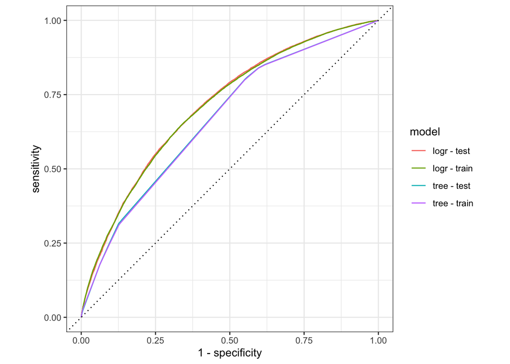

```r
res %>%
  yardstick::roc_curve(truth = delayed, p1) %>%
  ggplot2::autoplot()
```

#### PR Curve

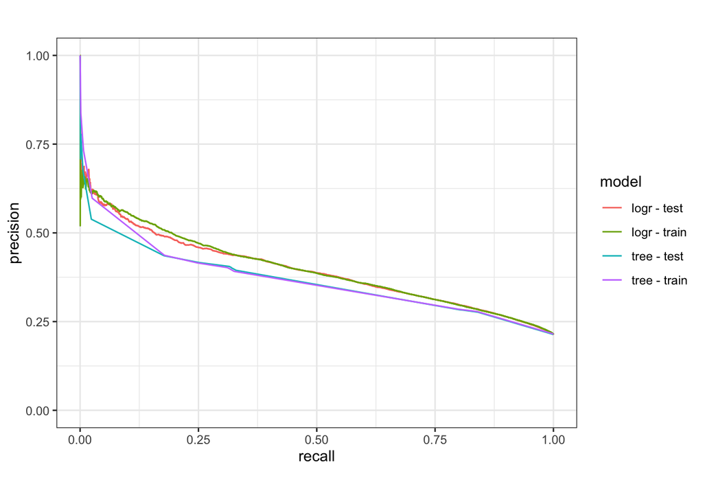

```r
res %>%
  yardstick::pr_curve(truth = delayed, p1) %>%
  ggplot2::autoplot()
```